**City College of San Francisco**

MATH 108 - Foundations of Data Science

# Lecture 20: Causality

Associated Textbook Sections: [12.2](https://inferentialthinking.com/chapters/12/2/Causality.html)

## Set Up the Notebook

```python
from datascience import *
import numpy as np
%matplotlib inline
import matplotlib.pyplot as plots
plots.style.use('fivethirtyeight')
```

# Table of Contents

## Causality

### Randomized Controlled Experiment

- Sample A: control group
- Sample B: treatment group
- If the treatment and control groups are selected at random, then you can make causal conclusions.
- Any difference in outcomes between the two groups could be due to chance or the treatment.

### Demo: Randomized Control Experiment

Load the data in `bta.csv` that is associated with an experiment to assess whether or not Botox and be used to reduce pain.

```python
botox = Table.read_table('bta.csv')
botox.show()
```

| Group | Result |
| --- | --- |
| Control | 1 |
| Control | 1 |
| Control | 0 |
| Control | 0 |
| Control | 0 |
| Control | 0 |
| Control | 0 |
| Control | 0 |
| Control | 0 |
| Control | 0 |
| Control | 0 |
| Control | 0 |
| Control | 0 |
| Control | 0 |
| Control | 0 |
| Control | 0 |
| Treatment | 1 |
| Treatment | 1 |
| Treatment | 1 |
| Treatment | 1 |
| Treatment | 1 |
| Treatment | 1 |
| Treatment | 1 |
| Treatment | 1 |
| Treatment | 1 |
| Treatment | 0 |
| Treatment | 0 |
| Treatment | 0 |
| Treatment | 0 |
| Treatment | 0 |
| Treatment | 0 |

Compare the results for the two groups.

```python
botox.pivot('Result', 'Group')
```

| Group | 0.0 | 1.0 |
| --- | --- | --- |
| Control | 14 | 2 |
| Treatment | 6 | 9 |

```python
botox.group(['Group', 'Result'])
```

| Group | Result | count |
| --- | --- | --- |
| Control | 0 | 14 |
| Control | 1 | 2 |
| Treatment | 0 | 6 |
| Treatment | 1 | 9 |

```python
botox.group('Group')
```

| Group | count |
| --- | --- |
| Control | 16 |
| Treatment | 15 |

```python
2 / 16 #control proportion reduction in pain
```

```
0.125
```

```python
9 / 15 #treatment proportion reduction in pain
```

```
0.6
```

```python
# Using average here gives us proportions!
botox.group('Group', np.average)
```

| Group | Result average |
| --- | --- |
| Control | 0.125 |
| Treatment | 0.6 |

### Before the Randomization

- In the population there is one imaginary ticket for each of the 31 participants in the experiment.
- Each participant’s ticket looks like this:

[figure not shown]

### The Data

16 randomly picked tickets show:

[figure not shown]

The remaining 15 tickets show:

[figure not shown]

### The Hypotheses

- Null: In the population, the distribution of all potential control scores is the same as the distribution of all potential treatment scores. (The treatment has no effect.)
- Alternative: In the population, more of the potential treatment scores are 1 (pain improves) than the potential control scores.

### Demo: Testing the Hypothesis

Compute the observed difference in results for the treatment and control groups using the `difference_of_means` function.

```python
def difference_of_means(table, numeric_label, group_label):
    """
    Takes: name of table, column label of numerical variable,
    column label of group-label variable

    Returns: Difference of means of the two groups
    """

    #table with the two relevant columns
    reduced = table.select(numeric_label, group_label)

    # table containing group means
    means_table = reduced.group(group_label, np.average)

    # array of group means
    means = means_table.column(1)

    return means.item(1) - means.item(0)
```

```python
observed_diff = difference_of_means(botox, 'Result', 'Group')
observed_diff
```

```
0.475
```

Use `one_simulated_difference` to determine the chance of observing the above sample data if it were true that Botox had no impact on pain reduction.

```python
def one_simulated_difference(table, numeric_label, group_label):
    """
    Takes: name of table, column label of numerical variable,
    column label of group-label variable

    Returns: Difference of means of the two groups after shuffling labels
    """

    # array of shuffled labels
    shuffled_labels = table.sample(
        with_replacement = False).column(group_label)

    # table of numerical variable and shuffled labels
    shuffled_table = table.select(numeric_label).with_column(
        'Shuffled Label', shuffled_labels)

    return difference_of_means(
        shuffled_table, numeric_label, 'Shuffled Label')
```

```python
one_simulated_difference(botox, 'Result', 'Group')
```

```
0.08750000000000002
```

```python
simulated_diffs = make_array()

for __ in np.arange(1000):
    sim_diff = one_simulated_difference(botox, 'Result', 'Group')
    simulated_diffs = np.append(simulated_diffs, sim_diff)
```

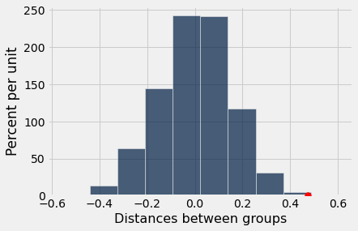

```python
Table().with_column('Distances between groups', simulated_diffs).\
        hist('Distances between groups')
plots.scatter(observed_diff, 0, color='red', s=60, zorder=3)
```

```python
p_value = sum(simulated_diffs >= observed_diff) / len(simulated_diffs)
reject_the_null = p_value < 0.05
reject_the_null
```

```
True
```

### Random Assignment & Shuffling

[figure not shown]

## An Error Probability

### Can the Conclusion be Wrong?

Yes.

|  | Null is True | Alternative is True |
| --- | --- | --- |
| Test favors the Null | ✅ | ❌ |
| Test favors the Alternative | ❌ | ✅ |

### An Error Probability

- The cutoff for the P-value is an error probability.
- If your cutoff is 5% and the null hypothesis happens to be true, then there is about a 5% chance that your test will reject the null hypothesis.

### P-value cutoff vs P-value

- P-value cutoff
  - Does not depend on observed data or simulation
  - Decide on it before seeing the results
  - Conventional values at 5% and 1%
  - Probability of hypothesis testing making an error
- P-value
  - Depends on the observed data and simulation
  - Probability under the null hypothesis that the test statistic is the observed value or further towards the alternative